# Lab 2B - Classification (Hard)

### 1. Explore the Data

1. Set the working directory to “C:/Workshop/Data”

```r
setwd("C:/Workshop/Data")
```

2. Load the “Risk.csv” file into a data frame called “policies”

```r
policies <- read.csv("Risk.csv")
```

3. Inspect the data with the head function

```r
head(policies)
```

```
##   Gender State State.Rate Height Weight      BMI Age Risk
## 1   Male    MA 0.10043368    184   67.8 20.02599  77 High
## 2   Male    VA 0.14172319    163   89.4 33.64824  82 High
## 3   Male    NY 0.09080315    170   81.2 28.09689  31  Low
## 4   Male    TN 0.11997276    175   99.7 32.55510  39  Low
## 5   Male    FL 0.11034460    184   72.1 21.29608  68 High
## 6   Male    WA 0.16292470    166   98.4 35.70910  64 High
```

4. Load the RColorBrewer package

```r
library(RColorBrewer)
```

5. Create a Set2 color palette with 3 colors

```r
palette <- brewer.pal(3, "Set2")
```

6. Create a scatterplot matrix colored by risk

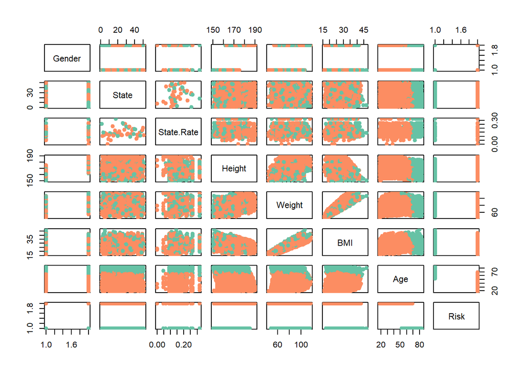

```r
plot(
  x = policies,
  col = palette[as.numeric(policies$Risk)],
  pch = 19)
```

7. Create a scatterplot of Age vs BMI colored by risk

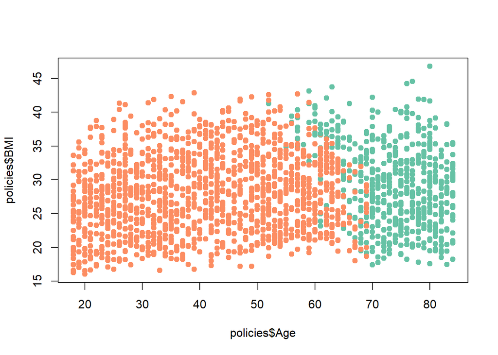

```r
plot(
  x = policies$Age,
  y = policies$BMI,
  col = palette[as.numeric(policies$Risk)],
  pch = 19)
```

8. Question: Does Risk appear to be linearly separable (i.e. could you draw a straight line that perfectly divides the two colors)?

### 2. Create Training and Test Set

1. Set seed to 42 to make randomness reproducable

```r
set.seed(42)
```

2. Load the caret package

```r
library(caret)
```

3. Create the training set indexes

```r
indexes <- createDataPartition(
  y = policies$Risk,
  p = 0.80,
  list = FALSE)
```

4. Create the training set from the indexes

```r
train <- policies[indexes, ]
```

5. Create the test set from the remaining rows

```r
test <- policies[-indexes, ]
```

6. Verify the number of rows in the training set

```r
nrow(train)
```

```
## [1] 1554
```

7. Verify the number of rows in the test set

```r
nrow(test)
```

```
## [1] 388
```

### 3. Predict with a k-Nearest Neighbors Classifier

1. Train a knn model to predict risk with k = 3  
   Note: Use the formula “Risk ~ Age + BMI + Gender + State.Rate”

```r
knnModel <- knn3(
  formula = Risk ~ Age + BMI + Gender + State.Rate,
  data = train,
  k = 3)
```

2. Predict the test set with the model

```r
knnPredictions <- predict(
  object = knnModel,
  newdata = test,
  type = "class")
```

3. Summarize the prediction results

```r
table(
  x = knnPredictions,
  y = test$Risk)
```

```
##       y
## x      High Low
##   High  112   6
##   Low     3 267
```

4. Create a confusion matrix

```r
knnMatrix <- confusionMatrix(
  data = knnPredictions,
  reference = test$Risk)
```

5. Inspect the results

```r
print(knnMatrix)
```

```
## Confusion Matrix and Statistics
##
##           Reference
## Prediction High Low
##       High  112   6
##       Low     3 267
##
##                Accuracy : 0.9768
##                  95% CI : (0.9564, 0.9893)
##     No Information Rate : 0.7036
##     P-Value [Acc > NIR] : <2e-16
##
##                   Kappa : 0.9448
##  Mcnemar's Test P-Value : 0.505
##
##             Sensitivity : 0.9739
##             Specificity : 0.9780
##          Pos Pred Value : 0.9492
##          Neg Pred Value : 0.9889
##              Prevalence : 0.2964
##          Detection Rate : 0.2887
##    Detection Prevalence : 0.3041
##       Balanced Accuracy : 0.9760
##
##        'Positive' Class : High
##
```

6. Question: What is the accuracy of the KNN classifier?

### 4. Predict with a Decision Tree Classifier

1. Load the tree package

```r
library(tree)
```

2. Train a tree model to predict Risk  
   Note: Use the formula “Risk ~ Age + BMI + Gender + State.Rate”

```r
treeModel <- tree(
  formula = Risk ~ Age + BMI + Gender + State.Rate,
  data = train)
```

3. Inspect the model

```r
summary(treeModel)
```

```
##
## Classification tree:
## tree(formula = Risk ~ Age + BMI + Gender + State.Rate, data = train)
## Variables actually used in tree construction:
## [1] "Age"    "BMI"    "Gender"
## Number of terminal nodes:  7
## Residual mean deviance:  0.09994 = 154.6 / 1547
## Misclassification error rate: 0.01673 = 26 / 1554
```

4. Plot the tree model and add text labels

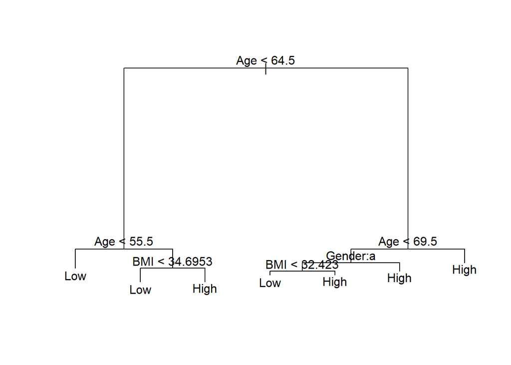

```r
plot(treeModel)
text(treeModel)
```

5. Predict test set with the model

```r
treePredictions <- predict(
  object = treeModel,
  newdata = test,
  type = "class")
```

6. Create a confusion matrix

```r
treeMatrix <- confusionMatrix(
  data = treePredictions,
  reference = test$Risk)
```

7. Inspect the results

```r
print(treeMatrix)
```

```
## Confusion Matrix and Statistics
##
##           Reference
## Prediction High Low
##       High  112   5
##       Low     3 268
##
##                Accuracy : 0.9794
##                  95% CI : (0.9598, 0.9911)
##     No Information Rate : 0.7036
##     P-Value [Acc > NIR] : <2e-16
##
##                   Kappa : 0.9508
##  Mcnemar's Test P-Value : 0.7237
##
##             Sensitivity : 0.9739
##             Specificity : 0.9817
##          Pos Pred Value : 0.9573
##          Neg Pred Value : 0.9889
##              Prevalence : 0.2964
##          Detection Rate : 0.2887
##    Detection Prevalence : 0.3015
##       Balanced Accuracy : 0.9778
##
##        'Positive' Class : High
##
```

8. Question: What is the accuracy of the decision tree classifier?

### 5. Predict with a Neural Network Classifier

1. Load nnet package

```r
library(nnet)
```

2. Train a neural network model  
   Note: Use the formula “Risk ~ Age + BMI + Gender + State.Rate”  
   Note: Use size of 10, decay of 0.0001, and maxit of 500

```r
neuralModel <- nnet(
  formula = Risk ~ Age + BMI + Gender + State.Rate,
  data = train,
  size = 10,
  decay = 0.0001,
  maxit = 500)
```

3. Inspect the model

```r
summary(neuralModel)
```

```
## a 4-10-1 network with 61 weights
## options were - entropy fitting  decay=1e-04
##  b->h1 i1->h1 i2->h1 i3->h1 i4->h1
##  19.84  -0.09  -0.44   0.05 -19.30
##  b->h2 i1->h2 i2->h2 i3->h2 i4->h2
##  -0.04   0.18   0.19   0.01   0.04
##  b->h3 i1->h3 i2->h3 i3->h3 i4->h3
##   0.10   2.53   3.33   0.07   0.05
##  b->h4 i1->h4 i2->h4 i3->h4 i4->h4
##  -0.04   0.23   0.19  -0.04   0.03
##  b->h5 i1->h5 i2->h5 i3->h5 i4->h5
##   0.13  -4.76   6.15   2.21   0.01
##  b->h6 i1->h6 i2->h6 i3->h6 i4->h6
##  13.92  -0.12  -0.16  -1.52  -7.19
##  b->h7 i1->h7 i2->h7 i3->h7 i4->h7
##  -0.02   0.18   0.04   0.02   0.02
##  b->h8 i1->h8 i2->h8 i3->h8 i4->h8
##  75.30  -0.98  -0.18 -20.59  70.02
##  b->h9 i1->h9 i2->h9 i3->h9 i4->h9
##   0.24   6.11  -8.92  11.50   4.71
##  b->h10 i1->h10 i2->h10 i3->h10 i4->h10
##   -5.56    0.16    0.07   -3.28  -13.27
##   b->o  h1->o  h2->o  h3->o  h4->o  h5->o  h6->o  h7->o  h8->o  h9->o
##   6.65 -43.26   6.77   6.00   6.59 -11.45  98.18   6.65 -19.41 -12.89
## h10->o
## -42.81
```

4. Load neural net tools

```r
library(NeuralNetTools)
```

5. Plot the neural network

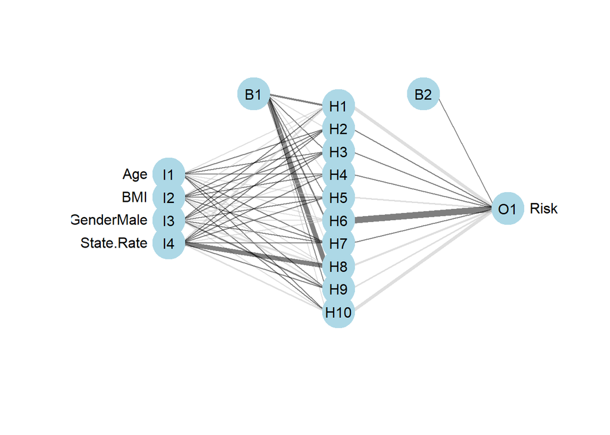

```r
plotnet(neuralModel, alpha=0.5)
```

6. Predict test set with the model

```r
neuralPredictions <- predict(
  object = neuralModel,
  newdata = test,
  type = "class")
```

7. Create a confusion matrix

```r
neuralMatrix <- confusionMatrix(
  data = as.factor(neuralPredictions),
  reference = test$Risk)
```

8. Inspect results

```r
print(neuralMatrix)
```

```
## Confusion Matrix and Statistics
##
##           Reference
## Prediction High Low
##       High  113   7
##       Low     2 266
##
##                Accuracy : 0.9768
##                  95% CI : (0.9564, 0.9893)
##     No Information Rate : 0.7036
##     P-Value [Acc > NIR] : <2e-16
##
##                   Kappa : 0.9451
##  Mcnemar's Test P-Value : 0.1824
##
##             Sensitivity : 0.9826
##             Specificity : 0.9744
##          Pos Pred Value : 0.9417
##          Neg Pred Value : 0.9925
##              Prevalence : 0.2964
##          Detection Rate : 0.2912
##    Detection Prevalence : 0.3093
##       Balanced Accuracy : 0.9785
##
##        'Positive' Class : High
##
```

9. Question: What is the accuracy of the neural network classifier?

### 6. Evaluate the Classifiers

1. Compare the accuracy of all 3 classifiers

```r
print(knnMatrix$overall[1])
```

```
##  Accuracy
## 0.9768041
```

```r
print(treeMatrix$overall[1])
```

```
##  Accuracy
## 0.9793814
```

```r
print(neuralMatrix$overall[1])
```

```
##  Accuracy
## 0.9768041
```

2. Question: Which model would you choose? Why?